# Popularne ścieżki - raport

## Spis treści

- Macierz przejścia i wstępna analiza
- Najpopularniejsze ścieżki

## Macierz przejścia i wstępna analiza

W celu analizy najpopularniejszych ścieżek po Re:generacji utworzyliśmy macierz przejść pomiędzy eksponatami. Tworząc tą macierz uwzględnialiśmy logowania trwające co najmniej 5 sekund, ponieważ uznaliśmy, że krótsze interakcje nie pozwalają na zapoznanie się z stanowiskiem, a szukamy ścieżek zawierających najbardziej atrakcyjne eksponaty.

Jej fragment wygląda następująco:

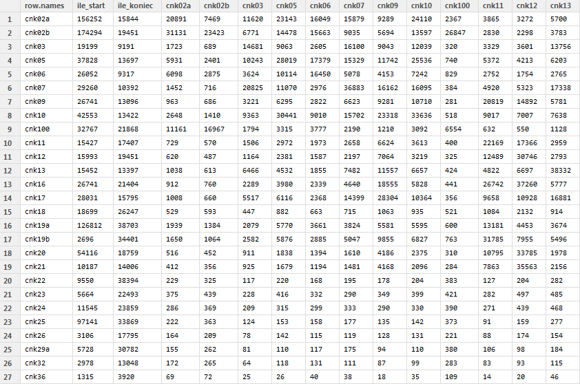

Na podstawie macierzy przejścia dla każdego stanowiska nanieśliśmy najbardziej popularne kierunki.

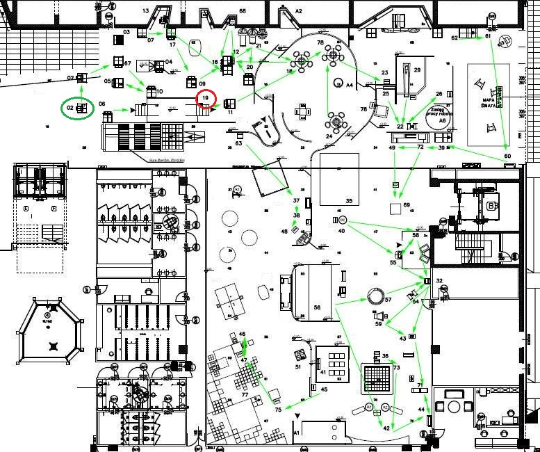

Można zauważyć, że zwiedzający najczęściej kierują się do najbliższych eksponatów. Kolorem zielonym zaznaczyliśmy eksponat, od którego zwiedzający najczęściej zaczynają. Jest to eksponat **cnk02b** czyli **Mózg podczas pracy** . Z kolei eksponat, na którym najczęsciej kończono zwiedzanie to **Sala Strachów** - zaznaczony na czerwono. Przeprowadzając analizę szukaliśmy eksponatów, do których mimo bliskiej odległości kieruje się mało użytkowników. Mogłoby to wskazywać na złe umiejscowienie eksponatu lub jego małą atrakcyjność. Chcieliśmy przeprowadzić analizę polegającą na sprawdzeniu, czy któryś z eksponatów jest pomijany przy przejściu od jego sąsiadów. W tym celu utworzyliśmy tabelkę, w której dla wybranego stanowiska umieszczamy pozycję popularności wśród trzech najbliższych sąsiadów. Pierwszy blok tabeli jest wyliczany na podstawie względnej odległości, czyli z uwzględnieniem ścian, natomiast drugi jest wyliczony z pominięciem ścian. Uporządkowaliśmy wyniki według malejącego minima sposród pozycji u sąsiadów, aby przyjrzeć się eksponatom podejrzanym o złe umiejscowienie.

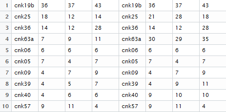

Przyjrzyjmy się paru stanowiskom, które odbiegają od normy. Pierwszy z nich to **cnk19b**, czyli **Sala strachów wyjście**. Dalekie pozycje wśród sąsiądów wynikają z tego, że jest to wyjście z eksponatu **Sala strachów**, a wejście do tego eksponatu nie znajduje się w trzech najlbiższych stanowiskach. Jeżeli rozszerzymy promień tak, aby wejście się w nim znalazło, pojawi się jedynka. Niska popularność wśród sąsiadów eksponatów **cnk36**, czyli **Zsieciowani** i **cnk63a**, czyli **Przesyłka do gwiazd** nas nie dziwi, ponieważ są to dwa najrzadziej odwiedzane eksponaty w galerii. Do ciekawych wniosków możemy dojść przyglądając się eksponatowi **cnk25**, czyli **Rodzinny interes**. W rankingu najrzadziej odwiedzanych eksponatów zajmuje dopiero 19stą pozycję, a wśród sąsiadów cieszy się małą popularnością. Aby dokładniej przeanalizować to stanowisko, wypisaliśmy pozycję **Rodzinnego interesu** wśród wszystkich eksponatów, zaczynając od najbliższego.

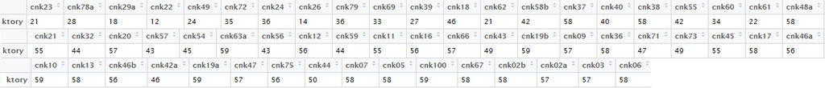

Jak widać, zwiedzający raczej omijają ten eksponat, bez względu na to, gdzie się znajdują. Możemy przypuszczać, że jest to spowodowane kiepskim położeniem eksponatu, który ograniczony jest ścianami i jest cięzko dostępny.

## Najpopularniejsze ścieżki

# Spis treści

- Streszczenie
- Wstęp
- Motywacja i uzasadnienie
- Najpopularniejsze ścieżki
- Podsumowanie

# Streszczenie

W raporcie tym została przeprowadzona analiza wyboru najpopularniejszej ścieżki. Za pomocą testów pokazano niemarkowskość zakładanego problemu, następnie umotywowano swoje podejście do Niego i jego rozwiązanie za pomocą analizy ścieżek o długości nie większej niż cztery.

# Wstęp

Do problemu wyszukania najpopularniejszej ścieżki można podchodzić na różne sposoby. Większość grup opiera się na danych otrzymanych za pomocą “jednokrokowej macierzy przejścia” - tzn. zliczeniu przejść bezpośrednio z jednego eksponatu do innego. O ile taka analiza pokazuje jak ludzie poruszają się bezpośrednio po kolejnych eskponatach, o tyle nijak ma się do kroków wykonywanych przez nich później- co udowodniliśmy zarówno empirycznie jak i matematycznie w naszej pracy.

W swojej pracy zastsowowaliśmy podejście bezpośrednie- zliczyliśmy wszystkie ścieżki dla każdej pary, trójki oraz czwórki i na tym oparliśmy dalszą analizę. W przypadku 5 i więcej eksponatów problem zaczyna się robić bardzo złożony ze względu na złożoność algorytmu działającego w tym celu - np. chcąc wyszukać najpopularniejszą ścieżkę zawierającą 5 eksponatów (nie skłądającej się wyłącznie z tych eksponatów), musielibyśmy zliczyć ilość zwiedzeń dla 5006386 kombinacji - czas działania takiego programu jest bardzo długi. Dlatego w analizie ścieżek długości większej niż 4 odeszliśmy od bezpośredniego podejścia do problemu.

# Motywacja i uzasadnienie

Jak wspomniane zostało na wstępie uzasadnimy dlaczego podejście do problemu wyszukiwania najpopularniejszej ścieżki za pomocą macierzy jednokrokowej jest błędne. Opierając się na tym pomyśle zakładamy, że zwiedzający poruszając się po kolejnych eksponatach biorą pod uwagę tylko fakt, w którym eksponacie obecnie się znajdują - można by więc opisać ścieżkę zwiedzającego za pomocą łańcucha Markowa z obliczoną przez nas jednokrokową macierzą przejścia. Przeprowadziliśmy testy w których weryfikujemy zgodność naszego założenia (o markowskości) z faktycznymi danymi. Nasza analiza została przeprowadzona w następujący sposób- policzyliśmy z naszych danych rzeczywiste k-krokowe macierze przejścia (tzn. do jakich eksponatów udają się zwiedzający w k-tym kroku, k=1,2,…,10). Analogicznie liczymy k-te macierze uwzgledniając założenie o markowskości (tzn. podnosimy naszą jednokrokową macierz do odpowiedniej potęgi). Następnie testem chi kwadrat porównywać będziemy zgodności rozkładów dla każdego wiersza dla każdej k-krokowej macierzy.

Wyniki (fragment) prezentuje się następująco (kolejne wiersze to porównanie macierzy k-krokowych, kolumny zaś zawierają wartość statystyki testu chi kwadrat zgodności rozkładów dla odpowiednich eksponatów).

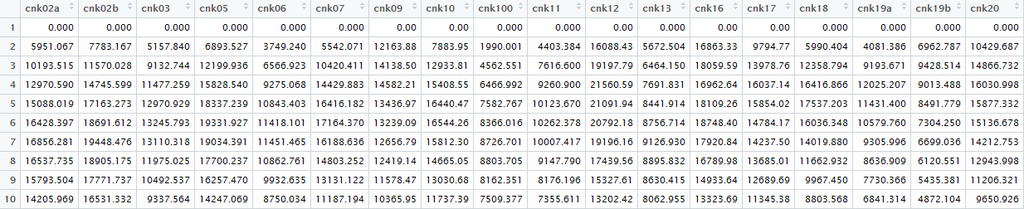

Zera w pierwszym wierszu nie dziwią- macierze jednokrokowe uzyskane zostały w ten sam sposób, zatem są idealnie zgodne (wartości wynoszące 0 mówią o przyjęciu hipotezy zerowej, która w teście chi kwadrat zakłada zgodność rozkładów). Dopiero w dalszej części tabeli możemy zauważyć spore rozbieżności pomiędzy badanymi przez nas rozkładami- wartość statytsyki testu chi-kwadrat osiąga nawet około 20 tysięcy, co jest bardzo dużą liczbą. Możemy więc z całą pewnością stwierdzić iż założenie o markowskości naszych danych byłoby błędem.

# Najpopularniejsze ścieżki

Na wstępie przypomnijmy, że analizę robimy tylko dla eksponatów, w których użytkownicy przebywali dłużej niż 5 sekund - tylko te uznaliśmy za warte uwagi. Dodatkowo jak stwierdziliśmy wcześniej, eksponat **nr cnk19a - Sala Strachów**, który był dostępny tylko w latach 2012-2014, mimo i tak zdecydowanie największej ilości odwiedzeń ze wszystkich, może nie znaleźć się wśród najpopularniejszych ścieżek właśnie z powodu braku danych w jednym roku- należy zatem pamiętać, że zapewne gdyby nie został wyłączony z użycia znalazłby się wśród najpopularniejszych ścieżek. Obliczenia jednak przeprowadzimy dla naszych danych, nie uwzględniając specjalnie braków na wyżej wymienionym eksponacie.

Sprawdźmy ilośc odwiedzeń poszczególnych eksponatów:

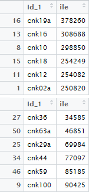

Daje się zatem zauważyć, że występują wprawdzie eksponaty odwiedzane sporo częściej niż inne- jak **cnk19a - Sala Strachów**, **cnk16 - Powąchaj mnie**, **cnk10 - Koń by się uśmiał**. Istnieją także eksponaty niezbyt popularne, jak **cnk36 - Zsieciowani**, **cnk63a - Przesyłka do gwiazd**, **cnk29a - Robot portrecista**, jednak jak wspominaliśmy już wcześniej - pierwsze dwa zostały usunięte w 2014 roku, zaś eksponat **Robot portrecista** jest eksponatem z długim czasem oczekiwania na interkację.

Zajmijmy się teraz policzeniem popularności ścieżek dla każdej pary:

10 najbardziej popularnych ścieżek to:

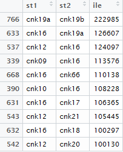

Widzimy więc, że para **cnk19a - Sala strachów (wejście)** i **cnk19b - Sala strachów (wyjście)** występuje w największej ilości ścieżek i co więcej- ilość występowań konkretnej pary dla pozostałych wyborów rozkłada się w miarę jednostajnie od wartości około 2 tysiący do około 120 tysięcy, jedynie wyżej wymieniona para zdecydowanie “odstaje” od tychże danych. Jednak istnieje na to logiczne wytłumaczenie - jest to tak naprawdę jeden eksponat - **Sala Strachów**, w którym czytniki kart są ustawione zarówno na wejściu jak i wyjściu.

Jak zauważyliśmy wcześniej (dla pojedynczych eksponatów) można by wyróżnić konkretne grupy par ze względu na odwiedziny, jednak my zajmiemy się tylko ścieżkami najczęściej występującymi na trasach zwiedzających.

Z tabeli dla par widzimy, że 3 najczęściej uczęszczane pary to (3 to subiektywna liczba):

-**cnk09 (Sztuka i emocje) - cnk16 (Powąchaj mnie)**

-**cnk16 (Powąchaj mnie) - cnk19a (Sala Strachów)**

-**cnk12 (Sztuczny czy szczery) - cnk16 (Powąchaj mnie)**

Występowanie w nich eksponatów numer 16 i 19 nie dziwi ze względu na to, iż są to 3 najczęściej odwiedzane eksponaty. Ważna jest jednak analiza z uwzględnieniem wcześniej podanej przez nas macierzy przejścia, o której pisaliśmy, że nie jest “miarodajna” ze względu na rozpatrywanie tylko bezpośrednich “przejść” pomiędzy eksponatami. Patrząc na tę macierz otrzymujemy, że ścieżka z eksponatu **nr 19a** do **nr 16** jest drugim najczęściej obieranym kierunkiem (**nr 11** najpopularniejszy), zaś **nr 16** do **nr 19a** - 10, z eksponatu **nr 16** najczęściej idą do **nr 12**, zaś z ścieżka z **nr 12** do **nr 16** jest 7 wyborem. Te dane mogą wskazywać, że rozpatrując macierz przejścia do znajdowania najpopularniejszej pary, obydwie również zostałaby uwzględnione. Jednak przejście z **nr 9** do **nr 16** jest na 4 pozycji, zaś z **nr 16** do **nr 9** - dopiero na 11. Bardzo mało prawdopodobnym jest więc, aby ścieżka ta została określona jako popularna za pomocą wyżej wspomnianej macierzy.

Z danych widać także, że tylko jedna z 6 najpopularniejszych ścieżek jest również najpopularniejszym jednokorokowym przejściem z jednego eksponatu na drugi (**16 -> 12**). Prostą konkluzją jest więc stwierdzenie, że wysnuwanie wniosków o najczęściej uczęszczanych ścieżkach za pomocą jednokrokowej macierzy przejścia jest błędem. Zatem fakt stwierdzony testami zostaje również potwierdzony empirycznie.

Przeanalizujmy teraz najpopularniejsze trójki:

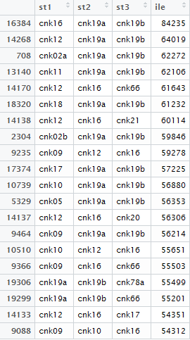

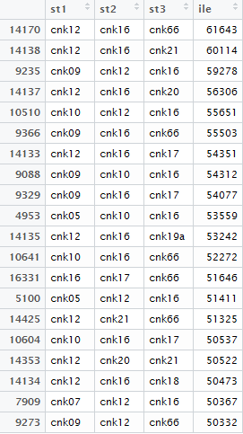

Cała tabela daje powody by sądzić, że nie ma jednej bądź kilku najpopularniejszych ścieżek- można je jedynie pogrupować.

Przeprowadźmy teraz analizę dla czwórek:

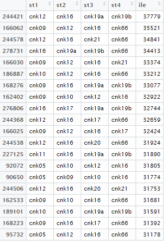

Na tym skończymy naszą analizę ścieżek. Z dużą pewnością można stwierdzić, że najpopularniejsza trasa składałaby się następującyh eksponatów:

-**cnk09 (Sztuka i emocje)**

-**cnk12 (Sztuczny czy szczery)**

-**cnk16 (Powąchaj mnie)**

-**cnk20 (Zrób sobie tatuaż)**

-**cnk21 (Młodzi fotografowie)**

-**cnk66 (Przesłyszałes się)**

a dalej najpewniej trzy eksponaty wspomniane przez nas wcześniej:

-**cnk05 - Strojenie mózgu**

-**cnk11 - Manipulator emocji**

-**cnk17 - Otwartość na doświadczenie**

# Podsumowanie

Podsumowując- ciężko jest wybrać jednoznacznie najpopularniejsze ścieżki na podstawie danych. Z całą pewnością można je pogrupować ze względu na liczbę odwiedzin, jednak jest to analiza mało mówiąca- już przed otrzymaniem danych można było stwierdzić, że powinna występować zależność na eksponaty mniej i bardziej uczęszczane. Udało nam się jednak znaleźć najpopularniejsze trasy cztero- i mniej elementowe, a także z dużą pewnością stwierdzić jak będą wyglądać dłuższe popularne ścieżki.

Należy także zauważyć, że wspomniany na samym początku tekstu eksponat **nr 19 - Sala Strachów**, tak jak przypuszczaliśmy nie znalazł się na najpopularniejszej ścieżce- mimo wszystko warto o nim pamiętać i według nas powinno się go na niej umieścić.

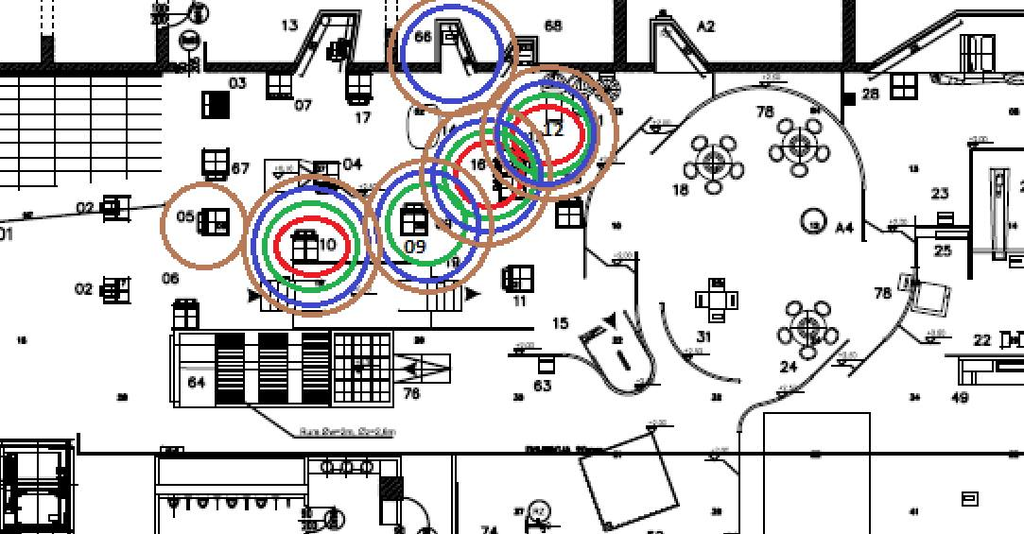

Rysunek obrazujący najpopularniejsze ścieżki skłania do pewnych wniosków- jednym z nich jest zauważenie, że wszystkie eksponaty na nim zaznaczone znajdują się bardzo blisko wejścia do Re:generacji- może to wskazywać na fakt, iż ludzie wchodzący na wystawę chętniej zapoznają się z eksponatami, jednak z biegiem czasu rzadziej użytkują kolejne.